# Lead Scoring

1. Project Idea
2. Reference
3. Project Goal(s)
4. Dataset
   1. Data Dictionary
5. Data Exploration
6. Observations from EDA
7. Transformations to test and train
8. Model Training and Evaluation
9. Model Visualization for Intrpretability

# Project Idea

I implemented a similar project on much larger scale professionally at **Admiral Markets** (Now *Admirals*). The idea was to score all the customers that signed up within last 1-10 minutes on the company's website in all 10+ regions, so that the model(s) could categorize them into three categories

1. **Hot:** having a large chance to convert to paid customer.
2. **Warm:** having a medium chance to convert to paid customer.
3. **Cold:** having a low chance to convert to paid customer.

The defintion of large/medium/low depends on actual dataset and its characteristics and on the business decision to decide how much work the sales team can handle. For example in my practical and real world application, we used the the following thresholds:

- Above 70% probability to convert = Hot Lead
- Between 33% and 70% probability to convert to paid = Warm Lead
- Below 33% is Cold Lead

By using above thresholds we were able to provide sales team a sorted list of customers based on their probability to move to paid customer, so every 1-10 minutes they could decide how much workload they could handle.

I implemented the project end-to-end i.e I build the data engineering pipelines connecting our internal CRM and other systems to DataWareHouse, did all the data analysis steps for feature engineering, data cleaning, quality checks and worked with different stakeholders/teams to make sure the data distributions does not change in silo's, everyone is informed, build,tested and deployed the model on Google cloud and used our interal API's to send results to the relevant teams in the format expected by them. Also managed all the documentation, presentations to the stakeholders and trainings for relevant teams. A lot more was done which I wish not to continue writing in order to keep this project manageable.

The impact of the project was 70-90% reduction in sales work and we were able to use the results in different departments. For example Customer Service only handled calls from high potential i.e HOT leads. Marketing used to identify our ideal customer etc. All improvements while keeping our conversion rate stable.

back to top

# References

1. https://pmc.ncbi.nlm.nih.gov/articles/PMC9890437/
2. https://link.springer.com/chapter/10.1007/978-0-387-74403-2_7
3. https://en.wikipedia.org/wiki/Uncertainty_coefficient

# Project Goals

From the dataset:

X Education wants to select the most promising leads, i.e. the leads that are most likely to convert into paying customers. The company requires you to build a model wherein you need to assign a lead score to each of the leads such that the customers with higher lead score h have a higher conversion chance and the customers with lower lead score have a lower conversion chance. The CEO, in particular, has given a ballpark of the target lead conversion rate to be around 80%.

My Opinion:

I believe the lead scoring cannot help with improving the conversion rate itself. The issue is that we do not know on a given time frame what would be the quality of the leads that would sign up, hence the conversion rate depends how good we are at Identifying the Ideal Customer Profile and market them well. Lead Scoring can help with differentiation valuable vs not-valuable customers, so we could plan our sales and marketing efforts better. So, in this specific project, my goals are 1. Exploratory Data Analysis(EDA) 2. Test and Evaluate an automated EDA python library(sweetviz), as the dataset has 30+ columns and I wish to keep my time spend as productive as possible.

This library also calculates associations within categorical variable.( Reference 2)

3. Train a simple model(decision tree) and showcase how it could help with interpretability. Interpretability is important as for business its always good to know why a customer converts, hence can help identity the Ideal Customer Profile as well.

back to top

# The Dataset

Source : https://www.kaggle.com/datasets/amritachatterjee09/lead-scoring-dataset/data

## Data Dictionary

| Column_Name | Description |
| --- | --- |
| Prospect ID | A unique ID with which the customer is identified. |
| Lead Number | A lead number assigned to each lead procured. |
| Lead Origin | The origin identifier with which the customer was identified to be a lead. Includes API, Landing Page Submission, etc. |
| Lead Source | The source of the lead. Includes Google, Organic Search, Olark Chat, etc. |
| Do Not Email | An indicator variable selected by the customer wherein they select whether of not they want to be emailed about the course or not. |
| Do Not Call | An indicator variable selected by the customer wherein they select whether of not they want to be called about the course or not. |
| Converted | The target variable. Indicates whether a lead has been successfully converted or not. |
| TotalVisits | The total number of visits made by the customer on the website. |
| Total Time Spent on Website | The total time spent by the customer on the website. |
| Page Views Per Visit | Average number of pages on the website viewed during the visits. |
| Last Activity | Last activity performed by the customer. Includes Email Opened, Olark Chat Conversation, etc. |
| Country | The country of the customer. |
| Specialization | The industry domain in which the customer worked before. Includes the level 'Select Specialization' which means the customer had not selected this option while filling the form. |
| How did you hear about X Education | The source from which the customer heard about X Education. |
| What is your current occupation | Indicates whether the customer is a student, umemployed or employed. |
| What matters most to you in choosing this course An option selected by the customer | indicating what is their main motto behind doing this course. |
| Search | Indicating whether the customer had seen the ad in any of the listed items. |
| Magazine |  |
| Newspaper Article |  |
| X Education Forums |  |
| Newspaper |  |
| Digital Advertisement |  |
| Through Recommendations | Indicates whether the customer came in through recommendations. |
| Receive More Updates About Our Courses | Indicates whether the customer chose to receive more updates about the courses. |
| Tags | Tags assigned to customers indicating the current status of the lead. |
| Lead Quality | Indicates the quality of lead based on the data and intuition the employee who has been assigned to the lead. |
| Update me on Supply Chain Content | Indicates whether the customer wants updates on the Supply Chain Content. |
| Get updates on DM Content | Indicates whether the customer wants updates on the DM Content. |
| Lead Profile | A lead level assigned to each customer based on their profile. |
| City | The city of the customer. |
| Asymmetric Activity Index | An index and score assigned to each customer based on their activity and their profile |
| Asymmetric Profile Index |  |
| Asymmetric Activity Score |  |
| Asymmetric Profile Score |  |
| I agree to pay the amount through cheque | Indicates whether the customer has agreed to pay the amount through cheque or not. |
| a free copy of Mastering The Interview | Indicates whether the customer wants a free copy of 'Mastering the Interview' or not. |
| Last Notable Activity | The last notable activity performed by the student. |

back to top

# Data Exploration

Steps:

1. Load the Dataset
2. Explore the column types and number
3. Look the continuous column distributions
4. Divide columns in categorial and continuous
5. Use **sweetviz library** for *automated Exploratory Data Analysis*

   The idea is to use python's batteries included approach to automate as much as possible. There is a ton of information that is provided by sweetviz, in the Obvservations from EDA section I interpret that into useful information for us.

back to top

```python
#Lets Load the dataset
import pandas as pd
ls_df = pd.read_csv('./Lead Scoring/Lead Scoring.csv')
ls_df.head()
```

|  | Prospect ID | Lead Number | Lead Origin | Lead Source | Do Not Email | Do Not Call | Converted | TotalVisits | Total Time Spent on Website | Page Views Per Visit | ... | Get updates on DM Content | Lead Profile | City | Asymmetrique Activity Index | Asymmetrique Profile Index | Asymmetrique Activity Score | Asymmetrique Profile Score | I agree to pay the amount through cheque | A free copy of Mastering The Interview | Last Notable Activity |
| --- | --- | --- | --- | --- | --- | --- | --- | --- | --- | --- | --- | --- | --- | --- | --- | --- | --- | --- | --- | --- | --- |
| 0 | 7927b2df-8bba-4d29-b9a2-b6e0beafe620 | 660737 | API | Olark Chat | No | No | 0 | 0.0 | 0 | 0.0 | ... | No | Select | Select | 02.Medium | 02.Medium | 15.0 | 15.0 | No | No | Modified |
| 1 | 2a272436-5132-4136-86fa-dcc88c88f482 | 660728 | API | Organic Search | No | No | 0 | 5.0 | 674 | 2.5 | ... | No | Select | Select | 02.Medium | 02.Medium | 15.0 | 15.0 | No | No | Email Opened |
| 2 | 8cc8c611-a219-4f35-ad23-fdfd2656bd8a | 660727 | Landing Page Submission | Direct Traffic | No | No | 1 | 2.0 | 1532 | 2.0 | ... | No | Potential Lead | Mumbai | 02.Medium | 01.High | 14.0 | 20.0 | No | Yes | Email Opened |
| 3 | 0cc2df48-7cf4-4e39-9de9-19797f9b38cc | 660719 | Landing Page Submission | Direct Traffic | No | No | 0 | 1.0 | 305 | 1.0 | ... | No | Select | Mumbai | 02.Medium | 01.High | 13.0 | 17.0 | No | No | Modified |
| 4 | 3256f628-e534-4826-9d63-4a8b88782852 | 660681 | Landing Page Submission | Google | No | No | 1 | 2.0 | 1428 | 1.0 | ... | No | Select | Mumbai | 02.Medium | 01.High | 15.0 | 18.0 | No | No | Modified |

5 rows × 37 columns

```python
#check column count and dtypes
ls_df.info()
```

```
<class 'pandas.core.frame.DataFrame'>
RangeIndex: 9240 entries, 0 to 9239
Data columns (total 37 columns):
 #   Column                                         Non-Null Count  Dtype
---  ------                                         --------------  -----
 0   Prospect ID                                    9240 non-null   object
 1   Lead Number                                    9240 non-null   int64
 2   Lead Origin                                    9240 non-null   object
 3   Lead Source                                    9204 non-null   object
 4   Do Not Email                                   9240 non-null   object
 5   Do Not Call                                    9240 non-null   object
 6   Converted                                      9240 non-null   int64
 7   TotalVisits                                    9103 non-null   float64
 8   Total Time Spent on Website                    9240 non-null   int64
 9   Page Views Per Visit                           9103 non-null   float64
```

[output cut: 29 more lines]

```python
ls_df.describe()
```

|  | Lead Number | Converted | TotalVisits | Total Time Spent on Website | Page Views Per Visit | Asymmetrique Activity Score | Asymmetrique Profile Score |
| --- | --- | --- | --- | --- | --- | --- | --- |
| count | 9240.000000 | 9240.000000 | 9103.000000 | 9240.000000 | 9103.000000 | 5022.000000 | 5022.000000 |
| mean | 617188.435606 | 0.385390 | 3.445238 | 487.698268 | 2.362820 | 14.306252 | 16.344883 |
| std | 23405.995698 | 0.486714 | 4.854853 | 548.021466 | 2.161418 | 1.386694 | 1.811395 |
| min | 579533.000000 | 0.000000 | 0.000000 | 0.000000 | 0.000000 | 7.000000 | 11.000000 |
| 25% | 596484.500000 | 0.000000 | 1.000000 | 12.000000 | 1.000000 | 14.000000 | 15.000000 |
| 50% | 615479.000000 | 0.000000 | 3.000000 | 248.000000 | 2.000000 | 14.000000 | 16.000000 |
| 75% | 637387.250000 | 1.000000 | 5.000000 | 936.000000 | 3.000000 | 15.000000 | 18.000000 |
| max | 660737.000000 | 1.000000 | 251.000000 | 2272.000000 | 55.000000 | 18.000000 | 20.000000 |

Lets divide the cols into categorical and continuous.

It seems most of the columns are categorical, except **TotalVisits, Total Time Spent on Website, Page Views Per Visit, Asymmetrique Activity Score and Asymmetrique Profile Score.**

Let's Explore the columns one by one

Raname cols as they have spaces in their names

```python
rename_dict = {}
for c in ls_df.columns:
    rename_dict[c] = c.replace(' ', '')
ls_df.rename(columns=rename_dict, inplace=True)
```

```python
ls_df.isna().sum()
```

```
ProspectID                                  0
LeadNumber                                  0
LeadOrigin                                  0
LeadSource                                 36
DoNotEmail                                  0
DoNotCall                                   0
Converted                                   0
TotalVisits                               137
TotalTimeSpentonWebsite                     0
PageViewsPerVisit                         137
LastActivity                              103
Country                                  2461
Specialization                           1438
HowdidyouhearaboutXEducation             2207
Whatisyourcurrentoccupation              2690
Whatmattersmosttoyouinchoosingacourse    2709
Search                                      0
Magazine                                    0
NewspaperArticle                            0
XEducationForums                            0
Newspaper                                   0
DigitalAdvertisement                        0
ThroughRecommendations                      0
ReceiveMoreUpdatesAboutOurCourses           0
Tags                                     3353
LeadQuality                              4767
UpdatemeonSupplyChainContent                0
GetupdatesonDMContent                       0
LeadProfile                              2709
City                                     1420
AsymmetriqueActivityIndex                4218
AsymmetriqueProfileIndex                 4218
AsymmetriqueActivityScore                4218
AsymmetriqueProfileScore                 4218
Iagreetopaytheamountthroughcheque           0
AfreecopyofMasteringTheInterview            0
LastNotableActivity                         0
dtype: int64
```

```python
#Split the dataset into train and test set, mention about stratified.
from sklearn.model_selection import train_test_split, cross_val_score, StratifiedKFold, RandomizedSearchCV
train, test = train_test_split(ls_df, test_size=.2, random_state=12, stratify=ls_df['Converted'])
print(f'train shape: {train.shape}')
print(f'test shape: {test.shape}')
```

```
train shape: (7392, 37)
test shape: (1848, 37)
```

```python
import sweetviz as sv
my_report = sv.analyze(train,pairwise_analysis='on')
my_report.show_notebook()
```

```
                                             |                                                                …
```

[interactive chart not shown]

# Observations from EDA

1. **ProspectID and LeadNumber** Columns are just ways to identify each lead in the system. We can keep one as an index to our df.
2. Most columns are categorical and only 5 of them are Numerical.
3. LeadSource and LeadOrigin has strong association. So keeping only **LeadOrigin**. Also it has only one value for **Quick Add Form** Category, so replace this with **Lead Add Form** .
4. **DoNotCall**: 99% values are *No*, So remove this column.
5. **TotalVisits**: Replace missing values with mean as it is a continuous column. This is correlated to **PageViewsPerVisit & TotalTimeSpentonWebsite**. So Keeping only **TotalVisits**.
6. **LastActivity**: Keep only top 6 values and replace mising values with one of them randomly. Strongly correlated to **Magazine, ReceiveMoreUpdatesAboutOurCourses, UpdatemeonSupplyChainContent, GetupdatesonDMContent, Iagreetopaytheamountthroughcheque, LastNotableActivity, DoNotEmail**. So keeping only *LastActivity.*
7. **Country**: Since majority leads are from India, it does not provide much information about lead quality. Drop it.
8. **Specialization**: keep only 4 top categories, move Select and others into single "Other" category.
9. **HowdidyouhearaboutXEducation**: keep only 2 online search and Word of Mouth categories, lump others into 'Other' category.
10. **Whatisyourcurrentoccupation**: keep only employed/unemployed categories.
11. **Whatmattersmosttoyouinchoosingacourse, Search, Magazine, NewspaperArticle, XEducationForums, Newspaper, DigitalAdvertisement, ThroughRecommendations, ReceiveMoreUpdatesAboutOurCourses,UpdatemeonSupplyChainContent,GetupdatesonDMContent, Iagreetopaytheamountthroughcheque**: only single category, remove it.
12. **Tags, LeadQuality, LeadProfile**: does not make sense on lead quality. Drop it.
13. **City**: As most leads are from mumbai, does not make sense to keep this column.
14. **AsymmetriqueActivityIndex, AsymmetriqueProfileIndex, AsymmetriqueProfileScore, AsymmetriqueActivityScore**: alot of missing values and no explanation provides. Drop it.
15. **AfreecopyofMasteringTheInterview**: clean column with no missing or weird values.
16. **LastNotableActivity**: since highly correlated to **LastActivity**. Drop it.

back to top

# Applying same Transformations to test and train

```python
train.drop(['ProspectID', 'LeadSource', 'DoNotCall', 'PageViewsPerVisit', 'TotalTimeSpentonWebsite',
            'Magazine', 'ReceiveMoreUpdatesAboutOurCourses', 'UpdatemeonSupplyChainContent',
            'GetupdatesonDMContent', 'Iagreetopaytheamountthroughcheque', 'LastNotableActivity', 'DoNotEmail',
           'Country', 'Whatmattersmosttoyouinchoosingacourse', 'Search', 'Magazine', 'NewspaperArticle',
            'XEducationForums', 'Newspaper', 'DigitalAdvertisement', 'ThroughRecommendations',
            'ReceiveMoreUpdatesAboutOurCourses','UpdatemeonSupplyChainContent','GetupdatesonDMContent',
            'Iagreetopaytheamountthroughcheque', 'Tags', 'LeadQuality', 'LeadProfile', 'City',
            'AsymmetriqueActivityIndex', 'AsymmetriqueProfileIndex', 'AsymmetriqueProfileScore', 'LastNotableActivity', 'AsymmetriqueActivityScore'], axis=1, inplace=True)

test.drop(['ProspectID', 'LeadSource', 'DoNotCall', 'PageViewsPerVisit', 'TotalTimeSpentonWebsite',
            'Magazine', 'ReceiveMoreUpdatesAboutOurCourses', 'UpdatemeonSupplyChainContent',
            'GetupdatesonDMContent', 'Iagreetopaytheamountthroughcheque', 'LastNotableActivity', 'DoNotEmail',
           'Country', 'Whatmattersmosttoyouinchoosingacourse', 'Search', 'Magazine', 'NewspaperArticle',
            'XEducationForums', 'Newspaper', 'DigitalAdvertisement', 'ThroughRecommendations',
            'ReceiveMoreUpdatesAboutOurCourses','UpdatemeonSupplyChainContent','GetupdatesonDMContent',
            'Iagreetopaytheamountthroughcheque', 'Tags', 'LeadQuality', 'LeadProfile', 'City',
            'AsymmetriqueActivityIndex', 'AsymmetriqueProfileIndex', 'AsymmetriqueProfileScore', 'LastNotableActivity', 'AsymmetriqueActivityScore'], axis=1, inplace=True)
```

```python
train.columns
```

```
Index(['LeadNumber', 'LeadOrigin', 'Converted', 'TotalVisits', 'LastActivity',
       'Specialization', 'HowdidyouhearaboutXEducation',
       'Whatisyourcurrentoccupation', 'AfreecopyofMasteringTheInterview'],
      dtype='object')
```

```python
train.index = train.LeadNumber
train.drop(['LeadNumber'], axis=1, inplace=True)

test.index = test.LeadNumber
test.drop(['LeadNumber'], axis=1, inplace=True)
```

```python
import warnings
warnings.filterwarnings('ignore', category=FutureWarning)
train['TotalVisits'].fillna((train['TotalVisits'].mean()), inplace=True)

# Replace missing values in test set with mean of train
test['TotalVisits'].fillna((train['TotalVisits'].mean()), inplace=True)
```

```python
# LastActivity
import random
top_cats = train['LastActivity'].value_counts().head(6).index.tolist()
train.loc[~train['LastActivity'].isin(top_cats), 'LastActivity'] = random.choice(top_cats)

# Replace top categories with top from TRAIN set
test.loc[~test['LastActivity'].isin(top_cats), 'LastActivity'] = random.choice(top_cats)
```

```python
#Specialization: top 4, rest into others
top_cats = train['Specialization'].value_counts().iloc[1: 5].index.tolist()
train.loc[~train['Specialization'].isin(top_cats), 'Specialization'] = 'Other'

# Replace top categories with top from TRAIN set
test.loc[~test['Specialization'].isin(top_cats), 'Specialization'] = 'Other'
```

```python
#HowdidyouhearaboutXEducation: keep only 2 online search and Word of Mouth categories, lump others into 'Other' category
top_cats = train['HowdidyouhearaboutXEducation'].value_counts().iloc[1: 3].index.tolist()
train.loc[~train['HowdidyouhearaboutXEducation'].isin(top_cats), 'HowdidyouhearaboutXEducation'] = 'Other'

# Replace top categories with top from TRAIN set
test.loc[~test['HowdidyouhearaboutXEducation'].isin(top_cats), 'HowdidyouhearaboutXEducation'] = 'Other'
train['HowdidyouhearaboutXEducation'].value_counts()
```

```
HowdidyouhearaboutXEducation
Other            6457
Online Search     647
Word Of Mouth     288
Name: count, dtype: int64
```

```python
#Whatisyourcurrentoccupation: keep only employed/unemployed categories.
train.loc[~train['Whatisyourcurrentoccupation'].isin(['Unemployed']), 'Whatisyourcurrentoccupation'] = 'Employed'

# Replace top categories with top from TRAIN set
test.loc[~test['Whatisyourcurrentoccupation'].isin(['Unemployed']), 'Whatisyourcurrentoccupation'] = 'Employed'
train['Whatisyourcurrentoccupation'].value_counts()
```

```
Whatisyourcurrentoccupation
Unemployed    4474
Employed      2918
Name: count, dtype: int64
```

```python
test.loc[test.LeadOrigin == 'Quick Add Form', 'LeadOrigin'] = 'Lead Add Form'
train.loc[train.LeadOrigin == 'Quick Add Form', 'LeadOrigin'] = 'Lead Add Form'
```

```python
train.columns, test.columns
```

```
(Index(['LeadOrigin', 'Converted', 'TotalVisits', 'LastActivity',
        'Specialization', 'HowdidyouhearaboutXEducation',
        'Whatisyourcurrentoccupation', 'AfreecopyofMasteringTheInterview'],
       dtype='object'),
 Index(['LeadOrigin', 'Converted', 'TotalVisits', 'LastActivity',
        'Specialization', 'HowdidyouhearaboutXEducation',
        'Whatisyourcurrentoccupation', 'AfreecopyofMasteringTheInterview'],
       dtype='object'))
```

```python
Y_train = train.Converted
X_train = train.drop(['Converted'], axis=1)

Y_test = test.Converted
X_test = test.drop(['Converted'], axis=1)
```

```python
#Train
dummies = pd.get_dummies(X_train[['LeadOrigin','LastActivity','Specialization', 'HowdidyouhearaboutXEducation',
                                'Whatisyourcurrentoccupation', 'AfreecopyofMasteringTheInterview']],drop_first=True)
X_train = pd.concat([X_train, dummies], axis=1)
X_train.drop(['LeadOrigin','LastActivity','Specialization', 'HowdidyouhearaboutXEducation',
              'Whatisyourcurrentoccupation', 'AfreecopyofMasteringTheInterview'], inplace=True, axis=1)

#Test
dummies = pd.get_dummies(X_test[['LeadOrigin','LastActivity','Specialization', 'HowdidyouhearaboutXEducation',
                                'Whatisyourcurrentoccupation', 'AfreecopyofMasteringTheInterview']],drop_first=True)
X_test = pd.concat([X_test, dummies], axis=1)
X_test.drop(['LeadOrigin','LastActivity','Specialization', 'HowdidyouhearaboutXEducation',
              'Whatisyourcurrentoccupation', 'AfreecopyofMasteringTheInterview'], inplace=True, axis=1)
len(X_test.columns), len(X_train.columns)
```

```
(17, 17)
```

Since Decision Tree's are robust and the whole idea of this project is to test a single model, we don't need to remove Outliers from TotalVisits.

# Model Training and Evaluation

back to top

```python
from sklearn.tree import DecisionTreeClassifier
from sklearn import metrics
clf = DecisionTreeClassifier(max_depth=3)
clf = clf.fit(X_train,Y_train)
Y_pred = clf.predict(X_test)
```

```python
print("Accuracy:",metrics.accuracy_score(Y_test, Y_pred))
```

```
Accuracy: 0.7359307359307359
```

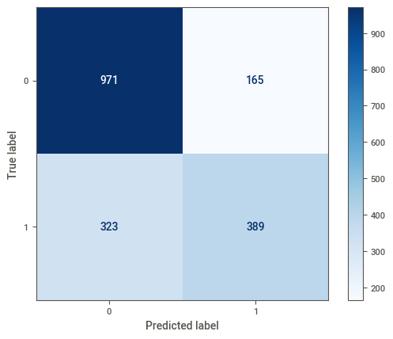

```python
import sklearn.metrics
disp = sklearn.metrics.ConfusionMatrixDisplay.from_predictions(
    y_pred=Y_pred,
    y_true=Y_test,
    cmap='Blues'
)
```

# Model Visualization for Intrpretability

back to top

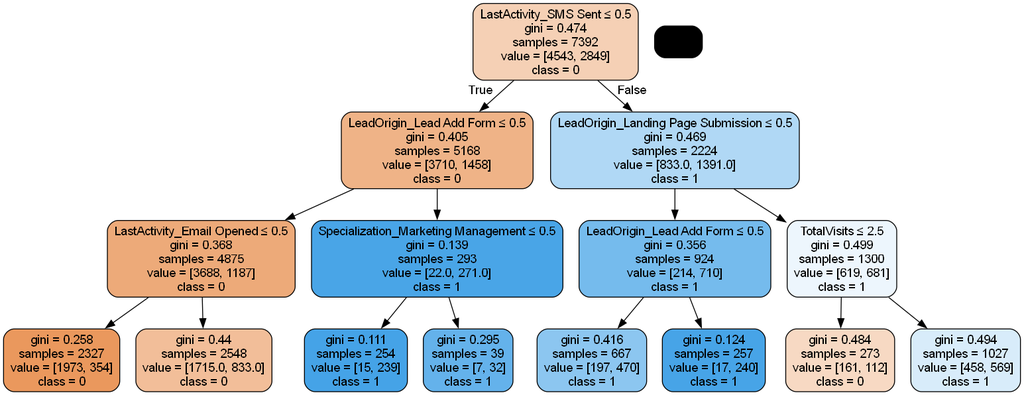

```python
from sklearn.tree import export_graphviz
from six import StringIO
from IPython.display import Image
import pydotplus
feature_cols = X_train.columns
dot_data = StringIO()
export_graphviz(clf, out_file=dot_data,
                filled=True, rounded=True,
                special_characters=True,feature_names = feature_cols,class_names=['0','1'])
graph = pydotplus.graph_from_dot_data(dot_data.getvalue())
graph.write_png('lead_scoring.png')
Image(graph.create_png())
```